# Using Mixed Linear Model as a method for Data Analysis

*24 October 2020*

by **[Linda N.](http://knlng.github.io)**

## Overview

This is one possible way to use linear mixed models with Python module `statsmodels` for data analysis. The data used in this notebook is from "http://www-personal.umich.edu/~bwest/rat_pup.dat" which is described on the website "https://www.pythonfordatascience.org/mixed-effects-regression-python/". This data belongs to a study from Jose Pinheiro and Doug Bates where they compared the birth weights of rat pups from different litters. Those litters differ in treatment conditions of mother rats which was either "high dose", "low dose" or "control".

```python
import pandas as pd
import matplotlib.pyplot as plt
import statsmodels.formula.api as smf
```

```python
df = pd.read_csv("http://www-personal.umich.edu/~bwest/rat_pup.dat", sep = "\t")
df
```

|  | pup_id | weight | sex | litter | litsize | treatment |
| --- | --- | --- | --- | --- | --- | --- |
| 0 | 1 | 6.60 | Male | 1 | 12 | Control |
| 1 | 2 | 7.40 | Male | 1 | 12 | Control |
| 2 | 3 | 7.15 | Male | 1 | 12 | Control |
| 3 | 4 | 7.24 | Male | 1 | 12 | Control |
| 4 | 5 | 7.10 | Male | 1 | 12 | Control |
| ... | ... | ... | ... | ... | ... | ... |
| 317 | 318 | 5.69 | Male | 27 | 9 | High |
| 318 | 319 | 6.36 | Male | 27 | 9 | High |
| 319 | 320 | 5.93 | Female | 27 | 9 | High |
| 320 | 321 | 5.74 | Female | 27 | 9 | High |
| 321 | 322 | 5.74 | Female | 27 | 9 | High |

322 rows × 6 columns

## Predict "weight" using `statsmodels`

```python
# enter relevant information into the variables

title_of_file = "weight_of_rat_pups"

dependent_variable = "weight"

# if variable xxx is categorical, it has to be wrapped in "C(xxx)"
# if the reference category aaa should be changed, the categorical variable
# has to be wrapped in "C(xxx, Treatment(aaa))"
list_of_fixed_effects = ["C(sex, Treatment('Male'))",
                         "litsize",
                         "C(treatment)",
                         "C(treatment):C(sex, Treatment('Male'))"]
random_effect = "litter"
```

```python
# fixed effects are linked together and separated with a plus
model_independent_var = '+'.join(list_of_fixed_effects)

model = smf.mixedlm(f"{dependent_variable}~1+{model_independent_var}",
                    groups=random_effect, data=df).fit()
print(model.summary())
```

```
                               Mixed Linear Model Regression Results
===================================================================================================
Model:                            MixedLM               Dependent Variable:               weight
No. Observations:                 322                   Method:                           REML
No. Groups:                       27                    Scale:                            0.1635
Min. group size:                  2                     Log-Likelihood:                   -200.5522
Max. group size:                  18                    Converged:                        Yes
Mean group size:                  11.9
---------------------------------------------------------------------------------------------------
                                                         Coef.  Std.Err.   z    P>|z| [0.025 0.975]
---------------------------------------------------------------------------------------------------
Intercept                                                 8.323    0.273 30.447 0.000  7.788  8.859
C(sex, Treatment('Male'))[T.Female]                      -0.412    0.073 -5.625 0.000 -0.555 -0.268
C(treatment)[T.High]                                     -0.906    0.192 -4.727 0.000 -1.282 -0.530
C(treatment)[T.Low]                                      -0.467    0.158 -2.952 0.003 -0.777 -0.157
C(treatment)[T.High]:C(sex, Treatment('Male'))[T.Female]  0.107    0.132  0.811 0.417 -0.151  0.366
C(treatment)[T.Low]:C(sex, Treatment('Male'))[T.Female]   0.084    0.106  0.794 0.427 -0.123  0.291
litsize                                                  -0.128    0.019 -6.845 0.000 -0.165 -0.092
litter Var                                                0.097    0.084
===================================================================================================
```

The result of this example shows either a positive or a negative effect (values in coefficient column) of the respective fixed effect on the weight of rat pups in this study. Furthermore, it shows that the interaction between "treatment" and "sex" ("C(treatment):C(sex, Treatment('Male'))") is not significant as the p-value is not < 0.05.

## Print the table of results as a figure

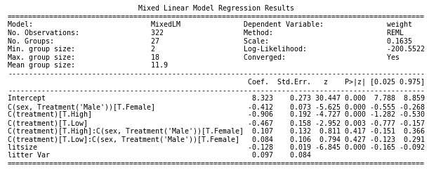

```python
plt.rc('figure', figsize=(5.5, 4))
plt.text(0.05, 0.02, str(model.summary()), {'fontsize': 10}, fontproperties = 'monospace')
plt.axis('off')
plt.tight_layout()

# in order to save the figure as a file, this line can be implemented:
# plt.savefig(f"{title_of_file}_mixedmodel.png", dpi=250)
```

## Save the relevant values in a data frame

```python
# save coefficient and p-value columns
coeff = model.params
pvals = model.pvalues

# create a data frame
model_df = pd.DataFrame({"dependent_variable":dependent_variable, "coeff":coeff, "pvals":pvals})

# in order to save this data frame as a csv-file, this line can be implemented:
# model_df.to_csv(f"{title_of_file}_data_frame.csv")

model_df
```

|  | dependent_variable | coeff | pvals |
| --- | --- | --- | --- |
| Intercept | weight | 8.323340 | 1.298902e-203 |
| C(sex, Treatment('Male'))[T.Female] | weight | -0.411688 | 1.853910e-08 |
| C(treatment)[T.High] | weight | -0.906056 | 2.281510e-06 |
| C(treatment)[T.Low] | weight | -0.467039 | 3.152915e-03 |
| C(treatment)[T.High]:C(sex, Treatment('Male'))[T.Female] | weight | 0.107023 | 4.171354e-01 |
| C(treatment)[T.Low]:C(sex, Treatment('Male'))[T.Female] | weight | 0.083866 | 4.274539e-01 |
| litsize | weight | -0.128382 | 7.669474e-12 |
| litter Var | weight | 0.590375 | 4.542771e-03 |

## References

- Python for Data Science: Mixed Effect Regression. 20 Aug 2020 https://www.pythonfordatascience.org/mixed-effects-regression-python/
- Statsmodels: Linear Mixed Effects Models. 20 Aug 2020 https://www.statsmodels.org/stable/examples/notebooks/generated/mixed_lm_example.html
- Stackoverflow: Python: How to save statsmodels results as image file? 20 Aug 2020 https://stackoverflow.com/questions/46664082/python-how-to-save-statsmodels-results-as-image-file
- Kshedden: Mixed Linear Models (MixedLM) in Python Statsmodels. 20 Aug 2020 https://github.com/kshedden/Statsmodels-MixedLM
- Jbhender: Linear Mixed Effects Models in R and Python. 20 Aug 2020 https://jbhender.github.io/Stats506/F18/GP/Group16.html